# Annual Greenhouse Gas (GHG) Air Emissions Accounts

### Group : Group 6

### Group Members :

| Name | Matrix Number |
| --- | --- |
| NG SUANG JOO | A21EC0102 |
| LING WAN YIN | A21EC0047 |
| FONG KHAH KHEH | A21EC0026 |
| KEE SHIN PEARL | A21EC0190 |

# About Dataset

**Dataset Description:**

The dataset, 'Annual Greenhouse Gas (GHG) Air Emissions Accounts,' downloaded from the [International Monetary Fund's Climate Change Dashboard website](https://climatedata.imf.org/), consists of 1186 records and 27 columns. To give an overview, this dataset is regarding the annual greenhouse gas emissions by activity and by region, it provides insights into annual GHG emissions by activity and region, with columns ranging from identifiers (ObjectId2) to detailed descriptors (CTS_Full_Descriptor) for the Climate Tracking System (CTS). The goal of this project is to analyze the annual greenhouse gas (GHG) emissions of various nations, investigate any relationships with economic status, look at historical trends for particular country groups, find anomalies, and possibly use machine learning techniques to predict future emissions.

**Dataset Attributes:**

- This dataset has a total of 1186 records with 27 columns of attributes.

| Column Name | Description |
| --- | --- |
| ObjectId2 | Identifier for the record |
| Country | Name of the country |
| ISO2 | Two-letter country code |
| ISO3 | Three-letter country code |
| Indicator | Type of greenhouse gas emission indicator |
| Unit | Measurement unit for the emission data |
| Source | Source of the emission data |
| CTS_Code | Code for the Climate Tracking System (CTS) |
| CTS_Name | Name of the Climate Tracking System |
| CTS_Full_Descriptor | Detailed descriptor for the Climate Tracking System |
| Industry | Industry associated with the emission data |
| Gas_Type | Type of greenhouse gas |
| Seasonal_Adjustment | Information on seasonal adjustment |
| Scale | Measurement scale for the emissions data |
| F2010 to F2022 | Annual greenhouse gas emissions data for each year |

## Downloading the Dataset

Please use the link below to access and download the dataset: [Annual Greenhouse Gas (GHG) Air Emissions Accounts](https://climatedata.imf.org/datasets/c8579761f19740dfbe4418b205654ddf/explore)

## Research Questions

1. Can machine learning models accurately predict a country's greenhouse gas emissions for the year 2022 based on historical data from 2013 to 2021?
1. How well can machine learning models differentiate between normal emission patterns and anomalies?
1. How well does the model predict annual greenhouse gas (GHG) emissions for the year 2022 based on historical data from the year 2013?
1. How well can machine learning models differentiate between various countries (Country column) based on their greenhouse gas emissions, considering different gas types and industries (Gas_Type and Industry columns)?
2. Which features have the most significant impact on predicting greenhouse gas emissions in a country?
3. Can we classify countries into different groups or clusters and observe patterns in their greenhouse gas emissions over the years, using clustering algorithms?
4. Can machine learning classify emissions patterns for different gas types?

## Load the Dataset

```python
import pandas as pd

file_path = "Annual_Greenhouse_Gas_(GHG)_Air_Emissions_Accounts.csv"

data = pd.read_csv(file_path)

data.head()
```

|  | ObjectId2 | Country | ISO2 | ISO3 | Indicator | Unit | Source | CTS_Code | CTS_Name | CTS_Full_Descriptor | ... | F2013 | F2014 | F2015 | F2016 | F2017 | F2018 | F2019 | F2020 | F2021 | F2022 |
| --- | --- | --- | --- | --- | --- | --- | --- | --- | --- | --- | --- | --- | --- | --- | --- | --- | --- | --- | --- | --- | --- |
| 0 | 1 | Advanced Economies | NaN | AETMP | Annual greenhouse gas (GHG) air emissions acco... | Million metric tons of CO2 equivalent | Organisation for Economic Co-operation and Dev... | ECNGA | Greenhouse Gas Emissions (GHG); Air Emissions ... | Environment, Climate Change, Greenhouse Gas Em... | ... | 190.048764 | 190.966649 | 193.338608 | 187.562070 | 189.440100 | 188.437327 | 187.905257 | 182.266715 | 187.438675 | 184.520601 |
| 1 | 2 | Advanced Economies | NaN | AETMP | Annual greenhouse gas (GHG) air emissions acco... | Million metric tons of CO2 equivalent | Organisation for Economic Co-operation and Dev... | ECNGA | Greenhouse Gas Emissions (GHG); Air Emissions ... | Environment, Climate Change, Greenhouse Gas Em... | ... | 1.029110 | 0.986873 | 1.011099 | 0.963934 | 0.950728 | 0.821667 | 0.783003 | 0.747345 | 0.702196 | 0.707047 |
| 2 | 3 | Advanced Economies | NaN | AETMP | Annual greenhouse gas (GHG) air emissions acco... | Million metric tons of CO2 equivalent | Organisation for Economic Co-operation and Dev... | ECNGA | Greenhouse Gas Emissions (GHG); Air Emissions ... | Environment, Climate Change, Greenhouse Gas Em... | ... | 1377.599894 | 1392.829858 | 1400.464829 | 1361.477669 | 1369.628014 | 1378.475201 | 1375.349001 | 1338.959570 | 1344.523950 | 1330.550899 |
| 3 | 4 | Advanced Economies | NaN | AETMP | Annual greenhouse gas (GHG) air emissions acco... | Million metric tons of CO2 equivalent | Organisation for Economic Co-operation and Dev... | ECNGA | Greenhouse Gas Emissions (GHG); Air Emissions ... | Environment, Climate Change, Greenhouse Gas Em... | ... | 633.493095 | 633.856107 | 639.263923 | 633.542996 | 639.543088 | 641.580792 | 634.344665 | 631.733383 | 630.457326 | 621.965004 |
| 4 | 5 | Advanced Economies | NaN | AETMP | Annual greenhouse gas (GHG) air emissions acco... | Million metric tons of CO2 equivalent | Organisation for Economic Co-operation and Dev... | ECNGA | Greenhouse Gas Emissions (GHG); Air Emissions ... | Environment, Climate Change, Greenhouse Gas Em... | ... | 553.028925 | 567.020229 | 566.851200 | 539.408671 | 539.694098 | 547.635416 | 552.316076 | 524.212127 | 525.925753 | 523.358247 |

5 rows × 27 columns

```python
data.shape
```

```
(1186, 27)
```

```python
data.dtypes
```

```
ObjectId2                int64
Country                 object
ISO2                   float64
ISO3                    object
Indicator               object
Unit                    object
Source                  object
CTS_Code                object
CTS_Name                object
CTS_Full_Descriptor     object
Industry                object
Gas_Type                object
Seasonal_Adjustment     object
Scale                   object
F2010                  float64
F2011                  float64
F2012                  float64
F2013                  float64
F2014                  float64
F2015                  float64
F2016                  float64
F2017                  float64
F2018                  float64
F2019                  float64
F2020                  float64
F2021                  float64
F2022                  float64
dtype: object
```

**Dataset Attributes**

```python
data.info()
```

```
<class 'pandas.core.frame.DataFrame'>
RangeIndex: 1186 entries, 0 to 1185
Data columns (total 27 columns):
 #   Column               Non-Null Count  Dtype
---  ------               --------------  -----
 0   ObjectId2            1186 non-null   int64
 1   Country              1186 non-null   object
 2   ISO2                 0 non-null      float64
 3   ISO3                 1186 non-null   object
 4   Indicator            1186 non-null   object
 5   Unit                 1186 non-null   object
 6   Source               1186 non-null   object
 7   CTS_Code             1186 non-null   object
 8   CTS_Name             1186 non-null   object
 9   CTS_Full_Descriptor  1186 non-null   object
```

[output cut: 19 more lines]

**Dataset Overview**

```python
data.describe()
```

|  | ObjectId2 | ISO2 | F2010 | F2011 | F2012 | F2013 | F2014 | F2015 | F2016 | F2017 | F2018 | F2019 | F2020 | F2021 | F2022 |
| --- | --- | --- | --- | --- | --- | --- | --- | --- | --- | --- | --- | --- | --- | --- | --- |
| count | 1186.000000 | 0.0 | 1.186000e+03 | 1.186000e+03 | 1.186000e+03 | 1.186000e+03 | 1.186000e+03 | 1.186000e+03 | 1.186000e+03 | 1.186000e+03 | 1.186000e+03 | 1.186000e+03 | 1.186000e+03 | 1.186000e+03 | 1.186000e+03 |
| mean | 696.345700 | NaN | 7.871620e+02 | 8.087643e+02 | 8.192881e+02 | 8.328579e+02 | 8.399073e+02 | 8.357463e+02 | 8.244420e+02 | 8.373828e+02 | 8.566463e+02 | 8.572490e+02 | 8.233470e+02 | 8.612265e+02 | 8.726990e+02 |
| std | 368.171291 | NaN | 2.986214e+03 | 3.094635e+03 | 3.146775e+03 | 3.207087e+03 | 3.240924e+03 | 3.219070e+03 | 3.170544e+03 | 3.228680e+03 | 3.315027e+03 | 3.325371e+03 | 3.214787e+03 | 3.377211e+03 | 3.419009e+03 |
| min | 1.000000 | NaN | -4.440000e-15 | -9.380000e-15 | -5.880000e-15 | -9.100000e-15 | -1.550000e-15 | -3.550000e-15 | -1.950000e-14 | -1.780000e-15 | -3.110000e-15 | -1.780000e-15 | -5.770000e-15 | -8.880000e-15 | -7.110000e-15 |
| 25% | 416.250000 | NaN | 3.392096e+00 | 3.359107e+00 | 3.506533e+00 | 3.609378e+00 | 3.636859e+00 | 3.571706e+00 | 3.656092e+00 | 3.695662e+00 | 3.667269e+00 | 3.791645e+00 | 3.479830e+00 | 3.626157e+00 | 3.687516e+00 |
| 50% | 712.500000 | NaN | 4.115801e+01 | 4.153315e+01 | 4.287393e+01 | 4.364143e+01 | 4.393280e+01 | 4.345641e+01 | 4.388413e+01 | 4.522914e+01 | 4.678409e+01 | 4.622857e+01 | 4.559083e+01 | 4.725835e+01 | 4.866689e+01 |
| 75% | 1008.750000 | NaN | 3.577597e+02 | 3.600748e+02 | 3.660298e+02 | 3.686307e+02 | 3.785122e+02 | 3.798043e+02 | 3.780418e+02 | 3.853032e+02 | 3.886009e+02 | 3.882763e+02 | 3.604905e+02 | 3.759250e+02 | 3.780589e+02 |
| max | 1305.000000 | NaN | 4.624233e+04 | 4.760897e+04 | 4.832278e+04 | 4.912791e+04 | 4.960594e+04 | 4.939794e+04 | 4.882721e+04 | 4.965752e+04 | 5.082033e+04 | 5.092468e+04 | 4.903607e+04 | 5.128123e+04 | 5.196017e+04 |

## Data Cleaning and Preparation

### Missing value

```python
missing_values_per_column = data.isna().sum()

print("Missing values in each column:")
print(missing_values_per_column)
```

```
Missing values in each column:
ObjectId2                 0
Country                   0
ISO2                   1186
ISO3                      0
Indicator                 0
Unit                      0
Source                    0
CTS_Code                  0
CTS_Name                  0
CTS_Full_Descriptor       0
Industry                  0
Gas_Type                  0
Seasonal_Adjustment       0
Scale                     0
F2010                     0
F2011                     0
F2012                     0
F2013                     0
F2014                     0
F2015                     0
F2016                     0
F2017                     0
F2018                     0
F2019                     0
F2020                     0
F2021                     0
F2022                     0
dtype: int64
```

It shows that there are missing values in the ISO2 column.

### Drop the empty column 'ISO2'

Since the column 'ISO2' consists of null values, remove it as it does not display any important insights into the data.

```python
data.drop('ISO2', axis=1, inplace=True)
data
```

|  | ObjectId2 | Country | ISO3 | Indicator | Unit | Source | CTS_Code | CTS_Name | CTS_Full_Descriptor | Industry | ... | F2013 | F2014 | F2015 | F2016 | F2017 | F2018 | F2019 | F2020 | F2021 | F2022 |
| --- | --- | --- | --- | --- | --- | --- | --- | --- | --- | --- | --- | --- | --- | --- | --- | --- | --- | --- | --- | --- | --- |
| 0 | 1 | Advanced Economies | AETMP | Annual greenhouse gas (GHG) air emissions acco... | Million metric tons of CO2 equivalent | Organisation for Economic Co-operation and Dev... | ECNGA | Greenhouse Gas Emissions (GHG); Air Emissions ... | Environment, Climate Change, Greenhouse Gas Em... | Agriculture, Forestry and Fishing | ... | 190.048764 | 190.966649 | 193.338608 | 187.562070 | 189.440100 | 188.437327 | 187.905257 | 182.266715 | 187.438675 | 184.520601 |
| 1 | 2 | Advanced Economies | AETMP | Annual greenhouse gas (GHG) air emissions acco... | Million metric tons of CO2 equivalent | Organisation for Economic Co-operation and Dev... | ECNGA | Greenhouse Gas Emissions (GHG); Air Emissions ... | Environment, Climate Change, Greenhouse Gas Em... | Agriculture, Forestry and Fishing | ... | 1.029110 | 0.986873 | 1.011099 | 0.963934 | 0.950728 | 0.821667 | 0.783003 | 0.747345 | 0.702196 | 0.707047 |
| 2 | 3 | Advanced Economies | AETMP | Annual greenhouse gas (GHG) air emissions acco... | Million metric tons of CO2 equivalent | Organisation for Economic Co-operation and Dev... | ECNGA | Greenhouse Gas Emissions (GHG); Air Emissions ... | Environment, Climate Change, Greenhouse Gas Em... | Agriculture, Forestry and Fishing | ... | 1377.599894 | 1392.829858 | 1400.464829 | 1361.477669 | 1369.628014 | 1378.475201 | 1375.349001 | 1338.959570 | 1344.523950 | 1330.550899 |
| 3 | 4 | Advanced Economies | AETMP | Annual greenhouse gas (GHG) air emissions acco... | Million metric tons of CO2 equivalent | Organisation for Economic Co-operation and Dev... | ECNGA | Greenhouse Gas Emissions (GHG); Air Emissions ... | Environment, Climate Change, Greenhouse Gas Em... | Agriculture, Forestry and Fishing | ... | 633.493095 | 633.856107 | 639.263923 | 633.542996 | 639.543088 | 641.580792 | 634.344665 | 631.733383 | 630.457326 | 621.965004 |
| 4 | 5 | Advanced Economies | AETMP | Annual greenhouse gas (GHG) air emissions acco... | Million metric tons of CO2 equivalent | Organisation for Economic Co-operation and Dev... | ECNGA | Greenhouse Gas Emissions (GHG); Air Emissions ... | Environment, Climate Change, Greenhouse Gas Em... | Agriculture, Forestry and Fishing | ... | 553.028925 | 567.020229 | 566.851200 | 539.408671 | 539.694098 | 547.635416 | 552.316076 | 524.212127 | 525.925753 | 523.358247 |
| ... | ... | ... | ... | ... | ... | ... | ... | ... | ... | ... | ... | ... | ... | ... | ... | ... | ... | ... | ... | ... | ... |
| 1181 | 1301 | World | WLD | Annual greenhouse gas (GHG) air emissions acco... | Million metric tons of CO2 equivalent | Organisation for Economic Co-operation and Dev... | ECNGA | Greenhouse Gas Emissions (GHG); Air Emissions ... | Environment, Climate Change, Greenhouse Gas Em... | Water supply; sewerage, waste management and r... | ... | 165.312195 | 163.046659 | 165.504266 | 169.854553 | 173.961476 | 172.105045 | 168.275866 | 164.666578 | 174.697139 | 177.237293 |
| 1182 | 1302 | World | WLD | Annual greenhouse gas (GHG) air emissions acco... | Million metric tons of CO2 equivalent | Organisation for Economic Co-operation and Dev... | ECNGA | Greenhouse Gas Emissions (GHG); Air Emissions ... | Environment, Climate Change, Greenhouse Gas Em... | Water supply; sewerage, waste management and r... | ... | 8.664948 | 9.375556 | 10.159372 | 11.178932 | 12.260119 | 13.095187 | 13.327889 | 12.691501 | 11.731265 | 11.615250 |
| 1183 | 1303 | World | WLD | Annual greenhouse gas (GHG) air emissions acco... | Million metric tons of CO2 equivalent | Organisation for Economic Co-operation and Dev... | ECNGA | Greenhouse Gas Emissions (GHG); Air Emissions ... | Environment, Climate Change, Greenhouse Gas Em... | Water supply; sewerage, waste management and r... | ... | 2325.122735 | 2363.749204 | 2404.982343 | 2443.202214 | 2489.451028 | 2531.849241 | 2562.394065 | 2586.145910 | 2630.270486 | 2675.233742 |
| 1184 | 1304 | World | WLD | Annual greenhouse gas (GHG) air emissions acco... | Million metric tons of CO2 equivalent | Organisation for Economic Co-operation and Dev... | ECNGA | Greenhouse Gas Emissions (GHG); Air Emissions ... | Environment, Climate Change, Greenhouse Gas Em... | Water supply; sewerage, waste management and r... | ... | 2034.005878 | 2072.130529 | 2108.301375 | 2138.492867 | 2177.122459 | 2219.058459 | 2251.997128 | 2278.513920 | 2311.960509 | 2352.389167 |
| 1185 | 1305 | World | WLD | Annual greenhouse gas (GHG) air emissions acco... | Million metric tons of CO2 equivalent | Organisation for Economic Co-operation and Dev... | ECNGA | Greenhouse Gas Emissions (GHG); Air Emissions ... | Environment, Climate Change, Greenhouse Gas Em... | Water supply; sewerage, waste management and r... | ... | 117.139713 | 119.196460 | 121.017331 | 123.675862 | 126.106974 | 127.590550 | 128.793182 | 130.273912 | 131.881572 | 133.992032 |

1186 rows × 26 columns

### Duplicated rows

Now, let's check whether there are any duplicate rows.

```python
duplicated_rows = data.duplicated()

# Check if there are any duplicated rows
if duplicated_rows.any():
    print("There are duplicated rows in the DataFrame.")
    duplicated_df = data[duplicated_rows]
    print("Duplicated Rows:", duplicated_df)
    print(duplicated_df)

else:
    print("There are no duplicated rows found.")
```

```
There are no duplicated rows found.
```

### Select only the necessary columns

Selecting specific columns related to GHG emissions, such as the country, ISO code, industry, gas type, and emission values for different years, as they are the main data that we used in the analysis.

```python
selected_columns = ['ObjectId2', 'Country', 'ISO3','Industry', 'Gas_Type',
      'F2010','F2011', 'F2012', 'F2013', 'F2014', 'F2015',
      'F2016', 'F2017', 'F2018', 'F2019', 'F2020', 'F2021', 'F2022']
df = data[selected_columns]
df.head()
```

|  | ObjectId2 | Country | ISO3 | Industry | Gas_Type | F2010 | F2011 | F2012 | F2013 | F2014 | F2015 | F2016 | F2017 | F2018 | F2019 | F2020 | F2021 | F2022 |
| --- | --- | --- | --- | --- | --- | --- | --- | --- | --- | --- | --- | --- | --- | --- | --- | --- | --- | --- |
| 0 | 1 | Advanced Economies | AETMP | Agriculture, Forestry and Fishing | Carbon dioxide | 194.398492 | 191.201537 | 192.473034 | 190.048764 | 190.966649 | 193.338608 | 187.562070 | 189.440100 | 188.437327 | 187.905257 | 182.266715 | 187.438675 | 184.520601 |
| 1 | 2 | Advanced Economies | AETMP | Agriculture, Forestry and Fishing | Fluorinated gases | 0.900844 | 0.948342 | 0.955449 | 1.029110 | 0.986873 | 1.011099 | 0.963934 | 0.950728 | 0.821667 | 0.783003 | 0.747345 | 0.702196 | 0.707047 |
| 2 | 3 | Advanced Economies | AETMP | Agriculture, Forestry and Fishing | Greenhouse gas | 1370.031102 | 1350.212366 | 1334.456632 | 1377.599894 | 1392.829858 | 1400.464829 | 1361.477669 | 1369.628014 | 1378.475201 | 1375.349001 | 1338.959570 | 1344.523950 | 1330.550899 |
| 3 | 4 | Advanced Economies | AETMP | Agriculture, Forestry and Fishing | Methane | 641.415104 | 636.893906 | 637.064644 | 633.493095 | 633.856107 | 639.263923 | 633.542996 | 639.543088 | 641.580792 | 634.344665 | 631.733383 | 630.457326 | 621.965004 |
| 4 | 5 | Advanced Economies | AETMP | Agriculture, Forestry and Fishing | Nitrous oxide | 533.316661 | 521.168581 | 503.963505 | 553.028925 | 567.020229 | 566.851200 | 539.408671 | 539.694098 | 547.635416 | 552.316076 | 524.212127 | 525.925753 | 523.358247 |

## Data Aggregation and Group Operations

```python
grouped_df = df.groupby(['Country', 'Industry', 'Gas_Type']).sum().reset_index()
grouped_df
```

|  | Country | Industry | Gas_Type | ObjectId2 | ISO3 | F2010 | F2011 | F2012 | F2013 | F2014 | F2015 | F2016 | F2017 | F2018 | F2019 | F2020 | F2021 | F2022 |
| --- | --- | --- | --- | --- | --- | --- | --- | --- | --- | --- | --- | --- | --- | --- | --- | --- | --- | --- |
| 0 | Advanced Economies | Agriculture, Forestry and Fishing | Carbon dioxide | 1 | AETMP | 194.398492 | 191.201537 | 192.473034 | 190.048764 | 190.966649 | 193.338608 | 187.562070 | 189.440100 | 188.437327 | 187.905257 | 182.266715 | 187.438675 | 184.520601 |
| 1 | Advanced Economies | Agriculture, Forestry and Fishing | Fluorinated gases | 2 | AETMP | 0.900844 | 0.948342 | 0.955449 | 1.029110 | 0.986873 | 1.011099 | 0.963934 | 0.950728 | 0.821667 | 0.783003 | 0.747345 | 0.702196 | 0.707047 |
| 2 | Advanced Economies | Agriculture, Forestry and Fishing | Greenhouse gas | 3 | AETMP | 1370.031102 | 1350.212366 | 1334.456632 | 1377.599894 | 1392.829858 | 1400.464829 | 1361.477669 | 1369.628014 | 1378.475201 | 1375.349001 | 1338.959570 | 1344.523950 | 1330.550899 |
| 3 | Advanced Economies | Agriculture, Forestry and Fishing | Methane | 4 | AETMP | 641.415104 | 636.893906 | 637.064644 | 633.493095 | 633.856107 | 639.263923 | 633.542996 | 639.543088 | 641.580792 | 634.344665 | 631.733383 | 630.457326 | 621.965004 |
| 4 | Advanced Economies | Agriculture, Forestry and Fishing | Nitrous oxide | 5 | AETMP | 533.316661 | 521.168581 | 503.963505 | 553.028925 | 567.020229 | 566.851200 | 539.408671 | 539.694098 | 547.635416 | 552.316076 | 524.212127 | 525.925753 | 523.358247 |
| ... | ... | ... | ... | ... | ... | ... | ... | ... | ... | ... | ... | ... | ... | ... | ... | ... | ... | ... |
| 1181 | World | Water supply; sewerage, waste management and r... | Carbon dioxide | 1301 | WLD | 156.348730 | 157.792392 | 162.289961 | 165.312195 | 163.046659 | 165.504266 | 169.854553 | 173.961476 | 172.105045 | 168.275866 | 164.666578 | 174.697139 | 177.237293 |
| 1182 | World | Water supply; sewerage, waste management and r... | Fluorinated gases | 1302 | WLD | 5.958067 | 6.762982 | 7.890352 | 8.664948 | 9.375556 | 10.159372 | 11.178932 | 12.260119 | 13.095187 | 13.327889 | 12.691501 | 11.731265 | 11.615250 |
| 1183 | World | Water supply; sewerage, waste management and r... | Greenhouse gas | 1303 | WLD | 2202.583180 | 2240.447082 | 2284.232080 | 2325.122735 | 2363.749204 | 2404.982343 | 2443.202214 | 2489.451028 | 2531.849241 | 2562.394065 | 2586.145910 | 2630.270486 | 2675.233742 |
| 1184 | World | Water supply; sewerage, waste management and r... | Methane | 1304 | WLD | 1929.636985 | 1963.335951 | 1998.979760 | 2034.005878 | 2072.130529 | 2108.301375 | 2138.492867 | 2177.122459 | 2219.058459 | 2251.997128 | 2278.513920 | 2311.960509 | 2352.389167 |
| 1185 | World | Water supply; sewerage, waste management and r... | Nitrous oxide | 1305 | WLD | 110.639398 | 112.555757 | 115.072008 | 117.139713 | 119.196460 | 121.017331 | 123.675862 | 126.106974 | 127.590550 | 128.793182 | 130.273912 | 131.881572 | 133.992032 |

1186 rows × 18 columns

```python
grouped_df2 = df.groupby(['Country', 'ISO3']).sum()
grouped_df2
```

| Country | ISO3 | ObjectId2 | Industry | Gas_Type | F2010 | F2011 | F2012 | F2013 | F2014 | F2015 | F2016 | F2017 | F2018 | F2019 | F2020 | F2021 | F2022 |
| --- | --- | --- | --- | --- | --- | --- | --- | --- | --- | --- | --- | --- | --- | --- | --- | --- | --- |
| Advanced Economies | AETMP | 1275 | Agriculture, Forestry and FishingAgriculture, ... | Carbon dioxideFluorinated gasesGreenhouse gasM... | 61235.081402 | 60285.728297 | 59347.521653 | 59820.497248 | 59132.675332 | 58640.931446 | 54988.465274 | 54885.698048 | 55246.313968 | 53980.349912 | 49111.463716 | 51088.379393 | 51573.692798 |
| Africa | NA605 | 3096 | Agriculture, Forestry and FishingAgriculture, ... | Carbon dioxideGreenhouse gasMethaneNitrous oxi... | 11486.815188 | 11511.222768 | 12081.735282 | 12260.965324 | 12576.150508 | 12663.987400 | 12834.765240 | 13170.337927 | 13470.968985 | 13653.913887 | 13115.811200 | 13655.215618 | 13815.017655 |
| Americas | AMETMP | 5220 | Agriculture, Forestry and FishingAgriculture, ... | Carbon dioxideGreenhouse gasMethaneNitrous oxi... | 44586.762970 | 44296.052202 | 43785.648471 | 44733.470513 | 45055.882006 | 44389.977134 | 43598.416012 | 43509.225640 | 44060.358396 | 43575.120402 | 40038.987608 | 41992.622602 | 42676.310952 |
| Asia | ASIATMP | 11388 | Agriculture, Forestry and FishingAgriculture, ... | Carbon dioxideFluorinated gasesGreenhouse gasM... | 94736.605724 | 100699.015206 | 103688.108028 | 106543.435191 | 108818.252112 | 108687.752748 | 107010.227881 | 109793.283348 | 113524.320607 | 115012.910411 | 113897.362933 | 119241.464324 | 121393.520333 |
| Australia and New Zealand | NAANZ | 16625 | Agriculture, Forestry and FishingAgriculture, ... | Carbon dioxideFluorinated gasesGreenhouse gasM... | 2590.372836 | 2598.284319 | 2617.230045 | 2574.784892 | 2555.475032 | 2592.466295 | 2621.713028 | 2657.863877 | 2656.975118 | 2630.853649 | 2519.498344 | 2476.579283 | 2503.829657 |
| Central Asia | NACA | 19125 | Agriculture, Forestry and FishingAgriculture, ... | Carbon dioxideFluorinated gasesGreenhouse gasM... | 2554.277896 | 2594.989900 | 2604.235032 | 2638.717281 | 2802.613025 | 2826.815048 | 2881.128699 | 2979.505623 | 3088.738447 | 2983.906167 | 2881.646135 | 3026.021317 | 3113.225340 |
| Eastern Asia | NA510 | 19350 | Agriculture, Forestry and FishingAgriculture, ... | Carbon dioxideGreenhouse gasMethaneNitrous oxi... | 56370.403111 | 60722.367744 | 62288.345922 | 64600.775549 | 65132.889967 | 64265.766770 | 61407.343793 | 62615.492973 | 64842.683235 | 65987.081920 | 66492.977992 | 69707.761842 | 69964.936335 |
| Eastern Europe | NAEE | 23875 | Agriculture, Forestry and FishingAgriculture, ... | Carbon dioxideFluorinated gasesGreenhouse gasM... | 13754.834957 | 14094.427597 | 14058.846277 | 13660.749375 | 13406.877243 | 13232.070336 | 13353.954989 | 13602.289565 | 13923.956689 | 13720.240816 | 13147.001484 | 13777.575497 | 13439.233706 |
| Emerging and Developing Economies | EMDETMP | 26375 | Agriculture, Forestry and FishingAgriculture, ... | Carbon dioxideFluorinated gasesGreenhouse gasM... | 123734.234729 | 130150.151366 | 133943.582362 | 136691.131931 | 139291.092401 | 138950.811095 | 140320.369111 | 143744.368876 | 148034.992331 | 149718.379634 | 147032.823535 | 154036.556244 | 156266.975237 |
| Europe | EURTMP | 28875 | Agriculture, Forestry and FishingAgriculture, ... | Carbon dioxideFluorinated gasesGreenhouse gasM... | 31488.265267 | 31250.397587 | 31033.512336 | 30317.165899 | 29326.726371 | 29161.148317 | 29142.937181 | 29398.331510 | 29461.106072 | 28714.764550 | 26485.011502 | 27668.831072 | 27361.043008 |
| G20 | NA120 | 31375 | Agriculture, Forestry and FishingAgriculture, ... | Carbon dioxideFluorinated gasesGreenhouse gasM... | 146772.772122 | 151417.329609 | 153256.183116 | 155811.322364 | 157057.221768 | 156130.449347 | 152742.867393 | 155097.840519 | 158910.172956 | 158949.577128 | 152946.815850 | 160172.835548 | 162430.613526 |
| G7 | NA119 | 33875 | Agriculture, Forestry and FishingAgriculture, ... | Carbon dioxideFluorinated gasesGreenhouse gasM... | 46924.123965 | 46033.554909 | 45255.074076 | 45911.571951 | 45377.781482 | 44697.667888 | 43809.995412 | 43517.862949 | 43947.139756 | 42952.830227 | 38965.543528 | 40742.031610 | 41227.757233 |
| Latin America and the Caribbean | LACTMP | 32625 | Agriculture, Forestry and FishingAgriculture, ... | Carbon dioxideGreenhouse gasMethaneNitrous oxi... | 13671.259556 | 14054.730171 | 14500.502413 | 14687.380256 | 14780.189860 | 14704.584904 | 14615.536652 | 14645.488518 | 14377.569027 | 14376.621039 | 13560.373043 | 14243.674848 | 14475.813035 |
| Northern Africa | NANA9 | 33067 | Agriculture, Forestry and FishingAgriculture, ... | Carbon dioxideGreenhouse gasMethaneNitrous oxi... | 3604.573439 | 3493.068752 | 3799.761028 | 3758.584023 | 3818.249228 | 3867.865161 | 3933.048550 | 4103.038520 | 4210.431509 | 4114.094250 | 3892.611370 | 4274.258452 | 4362.455272 |
| Northern America | NA225 | 36585 | Agriculture, Forestry and FishingAgriculture, ... | Carbon dioxideGreenhouse gasMethaneNitrous oxi... | 30915.503416 | 30241.322033 | 29285.146053 | 30046.090256 | 30275.692148 | 29685.392233 | 28982.879367 | 28863.737125 | 29682.789370 | 29198.499366 | 26478.614569 | 27748.947755 | 28200.497911 |
| Northern Europe | NANE | 43025 | Agriculture, Forestry and FishingAgriculture, ... | Carbon dioxideFluorinated gasesGreenhouse gasM... | 4482.139377 | 4267.327603 | 4254.186508 | 4195.515059 | 4013.572523 | 3992.545245 | 3926.110633 | 3870.267775 | 3897.097947 | 3778.402833 | 3346.638477 | 3466.397596 | 3506.505316 |
| Oceania | OCETMP | 45525 | Agriculture, Forestry and FishingAgriculture, ... | Carbon dioxideFluorinated gasesGreenhouse gasM... | 2670.866979 | 2679.191904 | 2702.099905 | 2656.592264 | 2646.756741 | 2688.876946 | 2722.488055 | 2758.888500 | 2764.552249 | 2742.020280 | 2607.114006 | 2566.802025 | 2594.776092 |
| Other Oceania sub-regions | NAOOSR | 38220 | Agriculture, Forestry and FishingAgriculture, ... | Carbon dioxideGreenhouse gasMethaneNitrous oxi... | 80.494143 | 80.907585 | 84.869860 | 81.807372 | 91.281708 | 96.410651 | 100.775027 | 101.024623 | 107.577131 | 111.166631 | 87.615662 | 90.222742 | 90.946436 |
| South-eastern Asia | NASEA | 42871 | Agriculture, Forestry and FishingAgriculture, ... | Carbon dioxideGreenhouse gasMethaneNitrous oxi... | 9192.363349 | 9647.176156 | 9852.793101 | 9928.338948 | 10280.937507 | 10477.634951 | 10653.303588 | 11086.430387 | 11771.953459 | 12291.939349 | 11963.234645 | 12193.909661 | 12790.720944 |
| Southern Asia | NASA | 45782 | Agriculture, Forestry and FishingAgriculture, ... | Carbon dioxideGreenhouse gasMethaneNitrous oxi... | 17648.845908 | 18296.813076 | 19031.229847 | 19335.357123 | 20248.596620 | 20482.925952 | 21074.143723 | 21965.801405 | 22729.298906 | 22507.792916 | 21534.505406 | 22796.757947 | 23577.615381 |
| Southern Europe | NASE | 54375 | Agriculture, Forestry and FishingAgriculture, ... | Carbon dioxideFluorinated gasesGreenhouse gasM... | 5062.578136 | 5031.780952 | 4848.672372 | 4532.863975 | 4396.772255 | 4301.008575 | 4238.637317 | 4343.853929 | 4275.778901 | 4124.630795 | 3672.701478 | 3833.700847 | 3880.489439 |
| Sub-Saharan Africa | SSA | 48762 | Agriculture, Forestry and FishingAgriculture, ... | Carbon dioxideGreenhouse gasMethaneNitrous oxi... | 7882.241749 | 8018.154016 | 8281.974254 | 8502.381300 | 8757.901279 | 8796.122239 | 8901.716690 | 9067.299406 | 9260.537476 | 9539.819636 | 9223.199828 | 9380.957166 | 9452.562383 |
| Western Asia | NAWA | 59025 | Agriculture, Forestry and FishingAgriculture, ... | Carbon dioxideFluorinated gasesGreenhouse gasM... | 8970.715462 | 9437.668333 | 9911.504128 | 10040.246285 | 10353.214992 | 10634.610024 | 10994.308084 | 11146.052953 | 11091.646567 | 11242.190051 | 11024.998756 | 11517.013554 | 11947.022331 |
| Western Europe | NAWE | 61525 | Agriculture, Forestry and FishingAgriculture, ... | Carbon dioxideFluorinated gasesGreenhouse gasM... | 8188.712796 | 7856.861436 | 7871.807183 | 7928.037493 | 7509.504349 | 7635.524161 | 7624.234240 | 7581.920240 | 7364.272534 | 7091.490107 | 6318.670065 | 6591.157132 | 6534.814547 |
| World | WLD | 64025 | Agriculture, Forestry and FishingAgriculture, ... | Carbon dioxideFluorinated gasesGreenhouse gasM... | 184969.316121 | 190435.879669 | 193291.104011 | 196511.629183 | 198423.767737 | 197591.742555 | 195308.834371 | 198630.066923 | 203281.306313 | 203698.729539 | 196144.287257 | 205124.935630 | 207840.668039 |

# Analysis and visualization

**Greenhouse Gas Emissions Trend Over the Years (All Countries)**

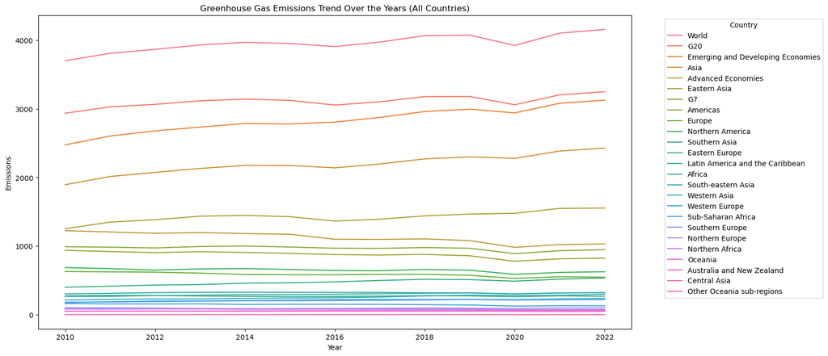

```python
import seaborn as sns
import matplotlib.pyplot as plt

selected_columns = ['Country', 'F2010', 'F2011', 'F2012', 'F2013', 'F2014', 'F2015', 'F2016', 'F2017', 'F2018', 'F2019', 'F2020', 'F2021', 'F2022']
df_selected = df[selected_columns]

# Melt the DataFrame
df_selected_melted = df_selected.melt(id_vars=['Country'], var_name='Year', value_name='Emissions')

# Extract the year and convert it to int
df_selected_melted['Year'] = df_selected_melted['Year'].str.extract('(\d+)', expand=False).astype(int)

# Sort the DataFrame by Year and Emissions
df_selected_melted = df_selected_melted.sort_values(by=['Year', 'Emissions'], ascending=[True, False])

# Visualization
plt.figure(figsize=(15, 8))
sns.lineplot(x='Year', y='Emissions', hue='Country', data=df_selected_melted, err_style=None)
plt.title('Greenhouse Gas Emissions Trend Over the Years (All Countries)')
plt.xlabel('Year')
plt.ylabel('Emissions')
plt.legend(title='Country', bbox_to_anchor=(1.05, 1), loc='upper left')
plt.show()
```

```python
df_selected_melted
```

|  | Country | Year | Emissions |
| --- | --- | --- | --- |
| 1173 | World | 2010 | 4.624233e+04 |
| 520 | G20 | 2010 | 3.669319e+04 |
| 1171 | World | 2010 | 3.364481e+04 |
| 420 | Emerging and Developing Economies | 2010 | 3.093356e+04 |
| 518 | G20 | 2010 | 2.837054e+04 |
| ... | ... | ... | ... |
| 14481 | Central Asia | 2022 | 0.000000e+00 |
| 14491 | Central Asia | 2022 | 0.000000e+00 |
| 14501 | Central Asia | 2022 | 0.000000e+00 |
| 14516 | Central Asia | 2022 | 0.000000e+00 |
| 14511 | Central Asia | 2022 | -7.110000e-15 |

15418 rows × 3 columns

**Analysis:**

**Pie chart for the distribution of Gas Types**

```
Gas Type Counts:
            Gas_Type  Count
0     Carbon dioxide    250
1     Greenhouse gas    250
2            Methane    250
3      Nitrous oxide    250
4  Fluorinated gases    186
```

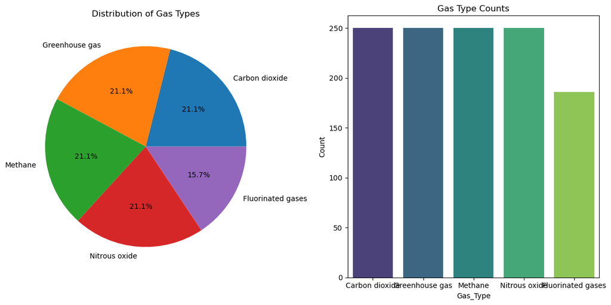

```python
gas_type_counts = data['Gas_Type'].value_counts()

gas_type_df = pd.DataFrame({'Gas_Type': gas_type_counts.index, 'Count': gas_type_counts.values})

print("Gas Type Counts:")
print(gas_type_df)

plt.figure(figsize=(12, 6))

# Pie chart
plt.subplot(1, 2, 1)
gas_type_counts.plot.pie(autopct='%1.1f%%')
plt.title('Distribution of Gas Types')
plt.ylabel('')

# Bar chart (count)
plt.subplot(1, 2, 2)
sns.barplot(x='Gas_Type', y='Count', data=gas_type_df, palette='viridis')
plt.title('Gas Type Counts')

plt.tight_layout()
plt.show()
```

**Analysis:**

The pie chart depicts the distribution of gas types in the dataset and includes five different categories. Carbon dioxide, greenhouse gases, methane and nitrous oxide each account for 21.1 percent of the total gas types, highlighting the relatively balanced representation of these major components of greenhouse gas emissions. Fluorinated gases, although a smaller proportion at 15.7 percent, still play a prominent role in the dataset. The equal counts for the top four gas types indicate a balanced representation, emphasizing the significance of monitoring various greenhouse gases. The lower count for Fluorinated gases could be due to their specific sources or their comparatively lower impact on emissions.

**Gas Type Distribution Across Industries**

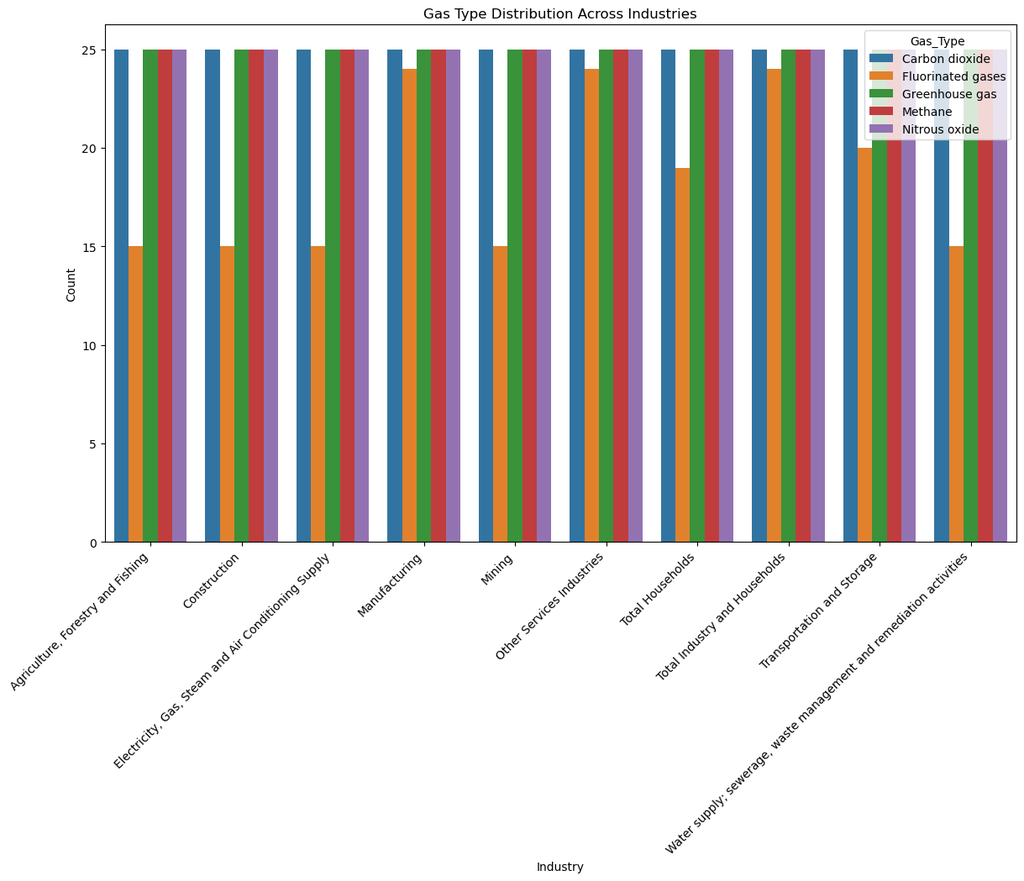

```python
# Countplot for gas types across industries
plt.figure(figsize=(14, 8))
sns.countplot(x='Industry', hue='Gas_Type', data=data)
plt.title('Gas Type Distribution Across Industries')
plt.xlabel('Industry')
plt.ylabel('Count')
plt.xticks(rotation=45, ha='right')
plt.show()
```

```python
count_table = data.groupby(['Industry', 'Gas_Type']).size().reset_index(name='Count')
count_table_pivot = count_table.pivot(index='Industry', columns='Gas_Type', values='Count').fillna(0).astype(int)
count_table_pivot
```

| Gas_Type Industry | Carbon dioxide | Fluorinated gases | Greenhouse gas | Methane | Nitrous oxide |
| --- | --- | --- | --- | --- | --- |
| Agriculture, Forestry and Fishing | 25 | 15 | 25 | 25 | 25 |
| Construction | 25 | 15 | 25 | 25 | 25 |
| Electricity, Gas, Steam and Air Conditioning Supply | 25 | 15 | 25 | 25 | 25 |
| Manufacturing | 25 | 24 | 25 | 25 | 25 |
| Mining | 25 | 15 | 25 | 25 | 25 |
| Other Services Industries | 25 | 24 | 25 | 25 | 25 |
| Total Households | 25 | 19 | 25 | 25 | 25 |
| Total Industry and Households | 25 | 24 | 25 | 25 | 25 |
| Transportation and Storage | 25 | 20 | 25 | 25 | 25 |
| Water supply; sewerage, waste management and remediation activities | 25 | 15 | 25 | 25 | 25 |

**Analysis:**

The chart shows types of gases by industry have a consistent distribution, with the same counts of carbon dioxide, greenhouse gases, methane and nitrous oxide (25) for each industry. However, the slightly higher counts of fluorinated gases in manufacturing and other services (24) indicate a relative increase in the presence of this type of gas compared to other industries.

**Total Emissions by Gas Type and Year for Country Types**

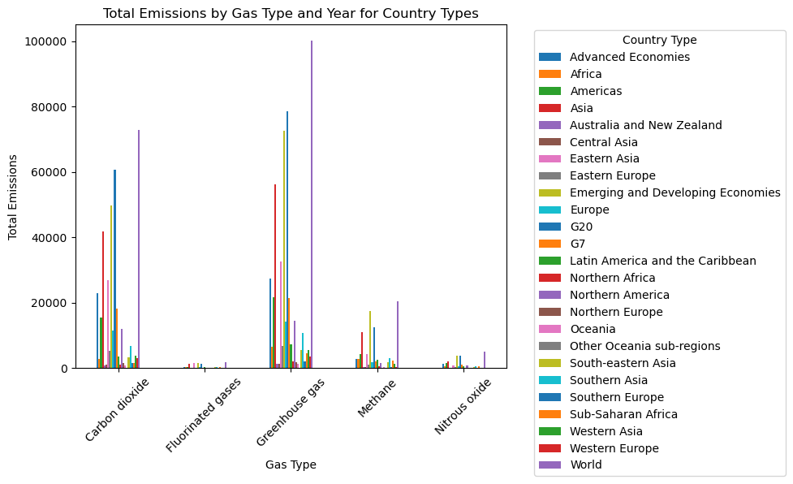

```python
import pandas as pd
import matplotlib.pyplot as plt

# Assuming your dataset contains columns for each year
year_columns = ['F2013', 'F2014', 'F2015', 'F2016', 'F2017', 'F2018', 'F2019', 'F2020', 'F2021', 'F2022']

data[year_columns] = data[year_columns].apply(pd.to_numeric, errors='coerce')

data_years_sum = data[year_columns].sum(axis=1)

data_plot = data[['Country', 'Gas_Type']].copy()
data_plot['Years'] = data_years_sum

data_pivot = data_plot.pivot_table(index='Gas_Type', columns='Country', values='Years')

# Visualization
data_pivot.plot(kind='bar', stacked=False, figsize=(10, 6))
plt.xlabel('Gas Type')
plt.ylabel('Total Emissions')
plt.title('Total Emissions by Gas Type and Year for Country Types')
plt.legend(title='Country Type', bbox_to_anchor=(1.05, 1), loc='upper left')
plt.xticks(rotation=45)
plt.tight_layout()
plt.show()
```

```python
data_pivot
```

| Country Gas_Type | Advanced Economies | Africa | Americas | Asia | Australia and New Zealand | Central Asia | Eastern Asia | Eastern Europe | Emerging and Developing Economies | Europe | ... | Northern Europe | Oceania | Other Oceania sub-regions | South-eastern Asia | Southern Asia | Southern Europe | Sub-Saharan Africa | Western Asia | Western Europe | World |
| --- | --- | --- | --- | --- | --- | --- | --- | --- | --- | --- | --- | --- | --- | --- | --- | --- | --- | --- | --- | --- | --- |
| Carbon dioxide | 22906.922106 | 2887.671104 | 15609.993225 | 41824.888138 | 913.369858 | 1006.376470 | 26831.458800 | 5245.389662 | 49888.655269 | 11526.230594 | ... | 1576.836588 | 946.794314 | 33.424456 | 3290.861437 | 6852.072616 | 1654.548080 | 1689.201936 | 3844.118813 | 3049.456263 | 72795.577375 |
| Fluorinated gases | 298.342142 | 380.715773 | 283.885424 | 1240.042543 | 26.083283 | 1.258408 | 1590.133882 | 101.773306 | 1517.157770 | 293.216643 | ... | 40.335469 | 26.083283 | NaN | 371.150359 | 362.082031 | 75.759794 | 247.252553 | 187.539274 | 75.348074 | 1815.499913 |
| Greenhouse gas | 27423.423356 | 6560.856687 | 21681.518563 | 56196.126494 | 1289.501959 | 1461.115854 | 32750.885519 | 6763.197485 | 72704.375020 | 14351.853274 | ... | 1899.652670 | 1337.443358 | 47.941399 | 5671.920172 | 10812.639769 | 2080.021876 | 4544.124870 | 5499.565180 | 3608.981243 | 100127.798377 |
| Methane | 2794.984473 | 2946.430320 | 4258.369681 | 10999.465995 | 298.354910 | 373.768437 | 4250.054131 | 1077.787947 | 17571.741747 | 1851.895657 | ... | 188.810381 | 310.564568 | 12.209657 | 1938.372594 | 3117.254444 | 261.149364 | 2298.646174 | 1320.016389 | 324.147966 | 20366.726220 |
| Nitrous oxide | 1423.174636 | 612.540532 | 1671.212946 | 2131.729820 | 51.693907 | 79.712540 | 874.305646 | 338.246570 | 3726.820234 | 680.510380 | ... | 93.670232 | 54.001193 | 2.307286 | 331.341033 | 698.479896 | 88.564637 | 482.100994 | 147.890704 | 160.028940 | 5149.994870 |

5 rows × 25 columns

**Line plot for Greenhouse Gas Emissions Trend Over the Years for Advanced Economies country and Emerging and Developing Economies country**

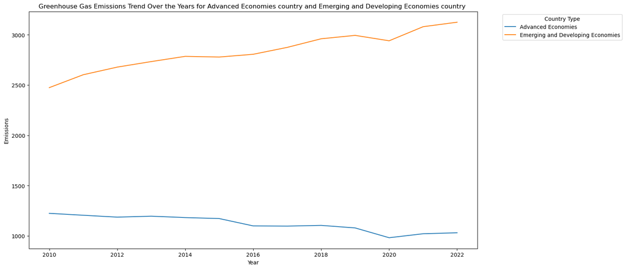

```python
import seaborn as sns
import matplotlib.pyplot as plt

selected_columns = ['Country', 'F2010', 'F2011', 'F2012', 'F2013', 'F2014', 'F2015', 'F2016', 'F2017', 'F2018', 'F2019', 'F2020', 'F2021', 'F2022']
df_selected = df[selected_columns]

advanced_economies = df_selected[df_selected['Country'] == 'Advanced Economies']
developing_economies = df_selected[df_selected['Country'] == 'Emerging and Developing Economies']

advanced_economies_melted = advanced_economies.melt(id_vars=['Country'], var_name='Year', value_name='Emissions')
developing_economies_melted = developing_economies.melt(id_vars=['Country'], var_name='Year', value_name='Emissions')

advanced_economies_melted['Year'] = advanced_economies_melted['Year'].str.extract('(\d+)', expand=False).astype(int)
developing_economies_melted['Year'] = developing_economies_melted['Year'].str.extract('(\d+)', expand=False).astype(int)

advanced_economies_melted = advanced_economies_melted.sort_values(by=['Year'])
developing_economies_melted = developing_economies_melted.sort_values(by=['Year'])

# Visualization for Advanced Economies
plt.figure(figsize=(15, 8))
sns.lineplot(x='Year', y='Emissions', data=advanced_economies_melted, label='Advanced Economies', err_style=None)

# Visualization for Emerging and Developing Economies
sns.lineplot(x='Year', y='Emissions', data=developing_economies_melted, label='Emerging and Developing Economies', err_style=None)

plt.title('Greenhouse Gas Emissions Trend Over the Years for Advanced Economies country and Emerging and Developing Economies country ')
plt.xlabel('Year')
plt.ylabel('Emissions')
plt.legend(title='Country Type', bbox_to_anchor=(1.05, 1), loc='upper left')
plt.show()
```

```python
print(advanced_economies_melted)
print(developing_economies_melted)
```

```
                Country  Year    Emissions
0    Advanced Economies  2010   194.398492
27   Advanced Economies  2010  1206.059472
28   Advanced Economies  2010    27.559390
29   Advanced Economies  2010    15.251566
30   Advanced Economies  2010  2307.194788
..                  ...   ...          ...
619  Advanced Economies  2022    37.695033
620  Advanced Economies  2022   309.517851
621  Advanced Economies  2022     0.028430
610  Advanced Economies  2022  3088.939497
649  Advanced Economies  2022    36.813425

[650 rows x 3 columns]
                               Country  Year     Emissions
0    Emerging and Developing Economies  2010    285.009179
27   Emerging and Developing Economies  2010    498.296577
28   Emerging and Developing Economies  2010     32.885487
29   Emerging and Developing Economies  2010      5.464750
30   Emerging and Developing Economies  2010   2123.767596
..                                 ...   ...           ...
619  Emerging and Developing Economies  2022    174.582521
620  Emerging and Developing Economies  2022   1489.635057
621  Emerging and Developing Economies  2022      0.019846
610  Emerging and Developing Economies  2022  11000.419530
649  Emerging and Developing Economies  2022     97.178607

[650 rows x 3 columns]
```

**Analysis:**

**Trend in GHG emissions over the years in Advanced Economies**

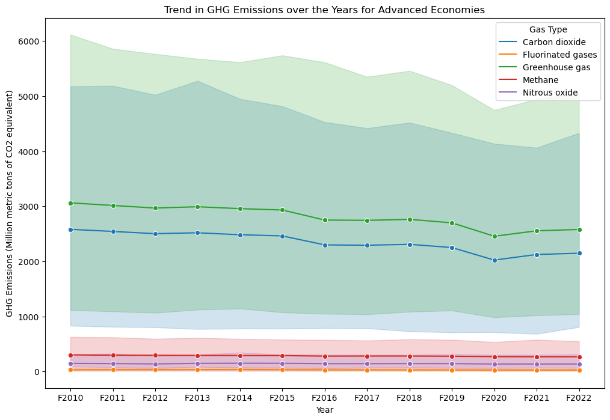

```python
group_column = 'Country'

selected_group = 'Advanced Economies'
group_data = df[df[group_column] == selected_group]

melted_data = pd.melt(group_data, id_vars=[group_column, 'ISO3', 'Industry', 'Gas_Type'],
                      value_vars=df.columns[5:], var_name='Year', value_name='GHG Emissions')

melted_data['GHG Emissions'] = pd.to_numeric(melted_data['GHG Emissions'], errors='coerce').fillna(0)

plt.figure(figsize=(12, 8))
sns.lineplot(x='Year', y='GHG Emissions', hue='Gas_Type', data=melted_data, marker='o')
plt.title(f'Trend in GHG Emissions over the Years for {selected_group}')
plt.xlabel('Year')
plt.ylabel('GHG Emissions (Million metric tons of CO2 equivalent)')
plt.legend(title='Gas Type')
plt.show()
```

```python
group_data_table = melted_data.pivot_table(values='GHG Emissions', index=['Country', 'Year'], columns='Gas_Type', aggfunc='sum').reset_index()
group_data_table = group_data_table[['Country', 'Year', 'Carbon dioxide', 'Fluorinated gases', 'Greenhouse gas', 'Methane', 'Nitrous oxide']]

print(group_data_table)
```

```
Gas_Type             Country   Year  Carbon dioxide  Fluorinated gases  \
0         Advanced Economies  F2010    25814.032797         318.841231
1         Advanced Economies  F2011    25429.000238         326.246809
2         Advanced Economies  F2012    25025.761796         329.494254
3         Advanced Economies  F2013    25182.772339         339.138349
4         Advanced Economies  F2014    24829.435784         345.769407
5         Advanced Economies  F2015    24616.462022         330.224311
6         Advanced Economies  F2016    22984.767357         297.379090
7         Advanced Economies  F2017    22924.164999         293.794113
8         Advanced Economies  F2018    23085.627762         291.454670
9         Advanced Economies  F2019    22503.277815         284.818004
10        Advanced Economies  F2020    20227.669062         268.872985
11        Advanced Economies  F2021    21241.129543         262.754786
12        Advanced Economies  F2022    21473.914378         269.215705

Gas_Type  Greenhouse gas      Methane  Nitrous oxide
0           30617.540701  3020.929392    1463.737281
1           30142.864145  2954.370556    1433.246549
2           29673.760823  2941.598772    1376.906009
3           29910.248623  2919.089596    1469.248341
4           29566.337666  2895.870422    1495.262053
5           29320.465723  2889.694801    1484.084589
6           27494.232636  2794.453562    1417.632630
7           27442.849021  2808.689374    1416.200540
8           27623.156982  2811.934816    1434.139738
9           26990.174954  2774.900240    1427.178898
10          24555.731859  2701.300722    1357.889088
11          25544.189698  2674.662632    1365.642735
12          25786.846398  2679.248570    1364.467746
```

**Analysis:**

Carbon dioxide is the most common greenhouse gas, and its emissions decline gradually from 2010 to 2022 in Advanced Economic Country. This decline may be attributed to increased awareness and efforts to transition to cleaner energy sources, as well as enhanced energy efficiency measures. At the same time, fluctuations in emissions of fluorinated gases, methane and nitrous oxide are indicative of changes in industrial activities and environmental policies. The overall decline in greenhouse gas emissions reflects a positive trend in the commitment of advanced economies to climate change mitigation.

**Correlation matrix of GHG Emissions by Year**

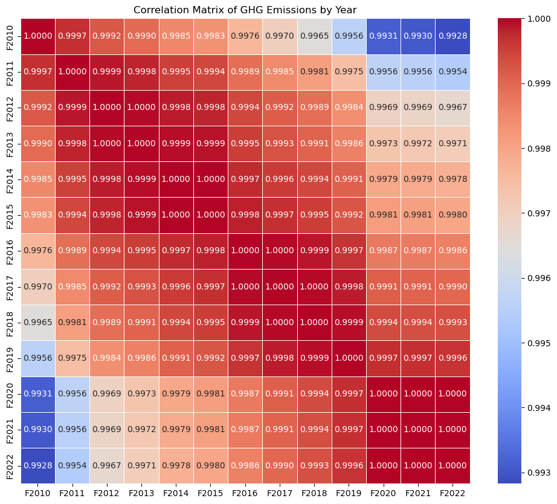

```python
economic_status_grouped = df.groupby('Country')[['F2010', 'F2011', 'F2012', 'F2013', 'F2014', 'F2015', 'F2016', 'F2017', 'F2018', 'F2019', 'F2020', 'F2021', 'F2022']].sum()

correlation_matrix = economic_status_grouped.corr()

plt.figure(figsize=(12, 10))
sns.heatmap(correlation_matrix, annot=True, cmap='coolwarm', fmt=".4f", linewidths=.5)
plt.title('Correlation Matrix of GHG Emissions by Year')
plt.show()
```

# Machine Learning

### **Research Question 1: Can machine learning models accurately predict a country's greenhouse gas emissions for the year 2022 based on historical data from 2013 to 2021?**

```
Mean Squared Error: 302.58223615099774
```

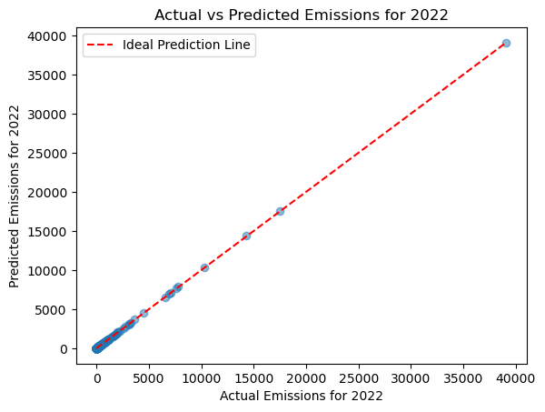

```python
import pandas as pd
from sklearn.model_selection import train_test_split
from sklearn.linear_model import LinearRegression
from sklearn.metrics import mean_squared_error
import matplotlib.pyplot as plt

data['Emissions_2022'] = data['F2022']

features = ['F2013', 'F2014', 'F2015', 'F2016', 'F2017', 'F2018', 'F2019', 'F2020', 'F2021']
target = 'Emissions_2022'

X = data[features]
y = data[target]

X_train, X_test, y_train, y_test = train_test_split(X, y, test_size=0.2, random_state=42)

# Initialize the linear regression model
model = LinearRegression()

# Train the model
model.fit(X_train, y_train)

# Make predictions on the test set
predictions = model.predict(X_test)

# Evaluate the model using Mean Squared Error
mse = mean_squared_error(y_test, predictions)
print(f'Mean Squared Error: {mse}')

# Scatter plot for actual vs predicted values
plt.scatter(y_test, predictions, alpha=0.5)
plt.plot([min(y_test), max(y_test)], [min(y_test), max(y_test)], linestyle='--', color='red', label='Ideal Prediction Line')
plt.xlabel('Actual Emissions for 2022')
plt.ylabel('Predicted Emissions for 2022')
plt.title('Actual vs Predicted Emissions for 2022')
plt.legend()
plt.show()
```

Model Training and Testing

- The dataset is split into training and testing sets (80% training, 20% testing) using `train_test_split`.
- Linear Regression is chosen as the predictive model.

Insights

- The model's Mean Squared Error is relatively low (302.58), suggesting reasonable accuracy in predicting emissions for 2022.
- The scatter plot visually compares actual vs predicted values, demonstrating a linear relationship.

The machine learning model built aims to predict a country's greenhouse gas emissions for the year 2022 based on historical data from 2013 to 2021.The MSE of approximately 302.58 indicates the average squared difference between the actual greenhouse gas emissions for the year 2022 and the emissions predicted by the linear regression model. Since the target variable is the emissions for 2022, the MSE value of 302.58 suggests that, on average, the squared difference between the predicted and actual emissions is around 302.58.The linear regression visualize the comparison between the actual emissions for 2022 and the model's predictions.